# Causal Modeling Workflow – NHEFS Example

Author

David Herman

Published

March 5, 2026

# 1 Objective

This document reproduces the original training example using the same dataset (NHEFS from the `causaldata` package) from Malcolm Barrett (2026). Moreover, it was addded extra PS matching approaches as suggested by Julien Tanniou (Saryga, 2025).

*Illustrative research question: Do individuals who quit smoking gain weight?*

# 2 Data source

We use the [`nhefs_complete`](https://wwwn.cdc.gov/nchs/nhanes/nhefs/) dataset from the `causaldata` package and restrict to uncensored individuals, as in the training material.

To keep the adjustment strategy transparent, we retain a reduced confounder set compared to the original study:

- `qsmk`: quit smoking indicator (treatment A)
- `wt82_71`: weight change 1971–1982 (outcome Y)
- `age`: age in years
- `sex`: sex (1 = male)
- `education`: education level, from 1 to 5

*Note: the correct approach would be conducting a literature review and having feedback from clinical experts as well as creating the DAGs (see below) and discussing with pharmaco-epidemiolgist. For simplification purpuses, here three baseline covariates were used.*

```r
library(causaldata) # Provides datasets used in causal inference, including the NHEFS
library(tidyverse) # Core data science workflow
library(ggdag) # Visualization tools for directed acyclic graphs (DAGs)
library(broom) # Converts model objects (e.g., lm, glm) into tidy df.
library(dagitty) # Formal specification and analysis of causal DAGs
library(MatchIt) # Implements propensity score matching algorithms
library(WeightIt) # Implements propensity score weighting and balancing approaches
library(cobalt) # Covariate balance diagnostics and visualization
library(ggplot2) # Grammar of graphics plotting system
library(rsample) # for bootstraps in correcting variance for iptw
library(glmnet) # LASSO log regression (appendix)
library(patchwork) # combined plots
```

```r
df <- nhefs_complete %>%
  filter(censored == 0) %>%
  dplyr::select(qsmk, wt82_71, age, sex, education)
```

# 3 Target Estimand and Identification

The objective is to estimate the Average Treatment Effect (ATE) of smoking cessation on weight change (continuous), defined as the mean difference (RD) in potential outcomes:

E[Y(1)] − E[Y(0)]

where:

- A = quitting smoking (`qsmk`)
- Y = weight change (`wt82_71`)

Because treatment is not randomized, treatment assignment depends on baseline covariates that also affect the outcome, creating confounding. Based on subject-matter knowledge and the causal structure illustrated in Figure 1, age, sex, and education influence both smoking cessation and weight change.

Under this causal model, the backdoor adjustment set:

Z = {age, sex, education}

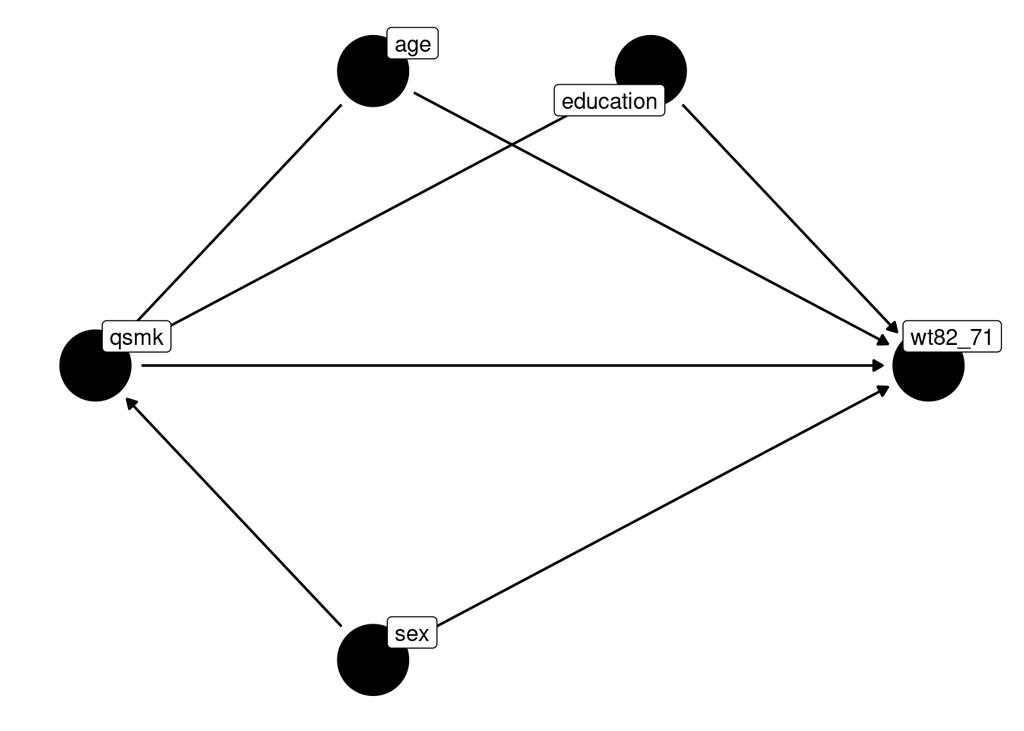

Figure 1: DAG structure

```r
# Age, sex, and education affect both smoking cessation and weight change.
dag <- dagitty(
  "
dag {

  qsmk [pos=\"0,0\"]
  wt82_71 [pos=\"3,0\"]

  age [pos=\"1,1\"]
  sex [pos=\"1,-1\"]
  education [pos=\"2,1\"]

  qsmk -> wt82_71

  age -> qsmk
  age -> wt82_71

  sex -> qsmk
  sex -> wt82_71

  education -> qsmk
  education -> wt82_71
}
"
)

ggdag(dag, text = FALSE, use_labels = "name") +
  theme_dag()
```

Identification of the ATE relies on the following assumptions:

- **Conditional exchangeability**: conditional on age, sex, and education, treatment assignment is independent of the potential outcomes.
- **Positivity**: for all covariate values Z, individuals have a non-zero probability of both receiving and not receiving treatment.
- **Consistency**: the observed outcome corresponds to the potential outcome under the treatment actually received.

# 4 Naive Association

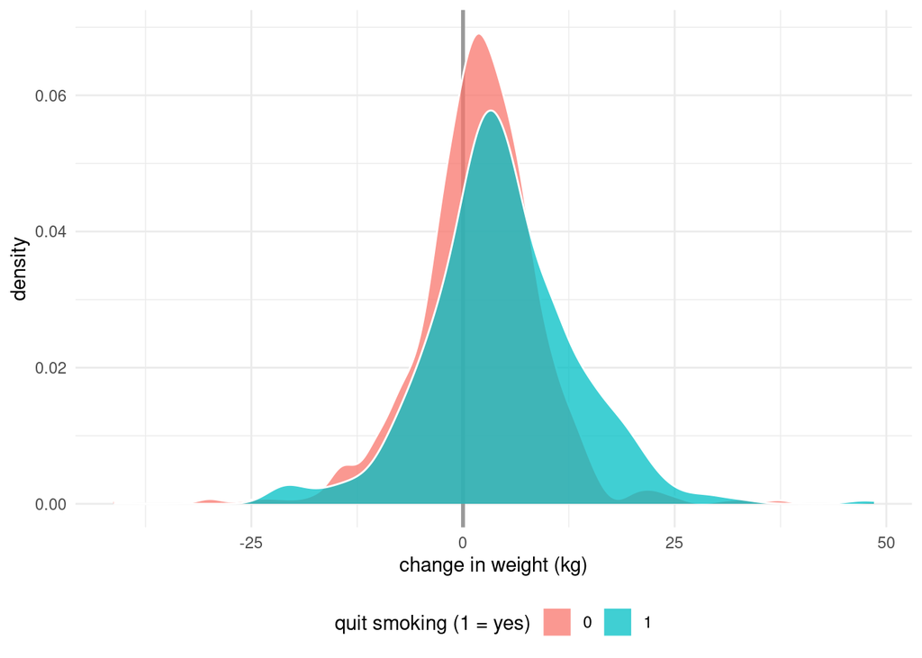

Figure 2: A density plot of change in weight for those who quit smoking and those who did not

```r
df %>%
  ggplot(aes(wt82_71, fill = factor(qsmk))) +
  geom_vline(xintercept = 0, color = "grey60", linewidth = 1) +
  geom_density(color = "white", alpha = .75, linewidth = .5) +
  theme_minimal() +
  theme(legend.position = "bottom") +
  labs(
    x = "change in weight (kg)",
    fill = "quit smoking (1 = yes)"
  )
```

```r
df %>%
  group_by(qsmk) %>%
  summarize(
    mean_weight_change = mean(wt82_71),
    sd = sd(wt82_71),
    n = n(),
    .groups = "drop"
  )
```

```
# A tibble: 2 × 4
   qsmk mean_weight_change    sd     n
  <dbl>              <dbl> <dbl> <int>
1     0               1.98  7.45  1163
2     1               4.53  8.75   403
```

This contrast represents an unadjusted association and may be confounded: ~2.5 KGs gained for quit vs. not quit. The mean difference in weight may suggest an association with quiting smoking. These results are the same as having a simple linear regression.

## 4.1 Naive OLS

Model with open backdoors via Z1, Z2 and Z3, risking biased for ATE estimation (unless randomized).

```r
# Fit naive OLS
naive_ml <- lm(wt82_71 ~ qsmk, data = df)
naive_ml
```

```
Call:
lm(formula = wt82_71 ~ qsmk, data = df)

Coefficients:
(Intercept)         qsmk
      1.984        2.541
```

```r
# Mean for qsmk=0 → 1.984
# Mean for qsmk=1 → 1.984 + 2.541 = 4.525
```

# 5 Outcome OLS - Multi-covariate adjustment

If Z blocks backdoors and model is correct, the βA targets ATE.

These models are sensitive to misspecification, omitted interactions or nonlinearity.

```r
# g-formula via regression
outcome_ml <- lm(wt82_71 ~ qsmk + sex + age + education, data = df)
outcome_ml
```

```
Call:
lm(formula = wt82_71 ~ qsmk + sex + age + education, data = df)

Coefficients:
(Intercept)         qsmk         sex1          age   education2   education3
     8.5674       3.1360      -0.5200      -0.1599       0.9579       0.6593
 education4   education5
     1.2206      -0.5183
```

# 6 Propensity Score Matching (PSM)

**“Counterfactual: what if everyone quit smoking vs. what if no one quit smoking”**

We estimate the propensity score (PS):

Pr(A = 1 | Z) = Pr(qsmk = 1 | age, sex, education)

```r
ps_model <- glm(
  qsmk ~ age + sex + education,
  data = df,
  family = binomial()
)

df$ps <- predict(ps_model, type = "response")

# Trim extreme values
df$ps <- pmin(pmax(df$ps, 0.01), 0.99)
```

```r
# Aim for |SMD| < 0.1 after adjustment
bal <- bal.tab(
  qsmk ~ age + sex + education,
  data = df,
  estimand = "ATE",
  un = TRUE # show unadjusted differences
)

bal
```

```
Balance Measures
               Type Diff.Un
age         Contin.  0.2820
sex          Binary -0.0799
education_1  Binary  0.0204
education_2  Binary -0.0451
education_3  Binary -0.0231
education_4  Binary -0.0071
education_5  Binary  0.0550

Sample sizes
    Control Treated
All    1163     403
```

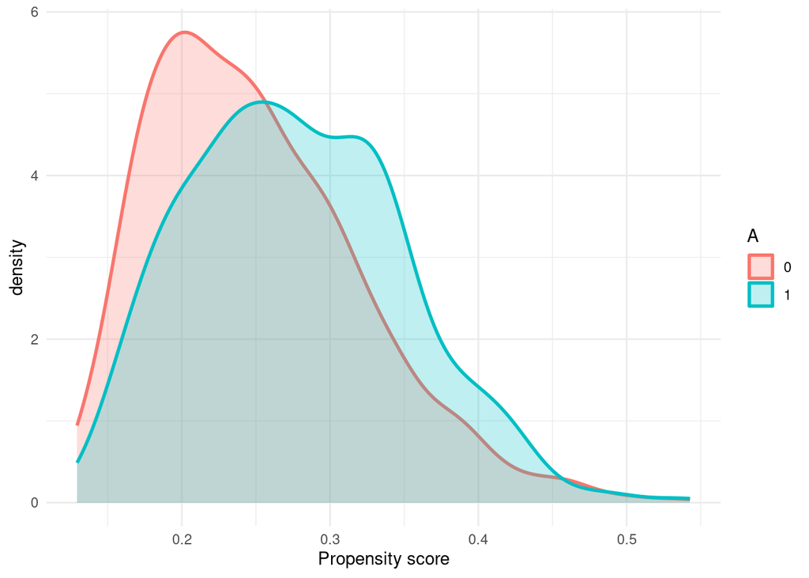

Figure 3: PS baseline imbalance - Raw PS overlap (before any method)

```r
# Raw PS overlap (before any method)
ggplot(df, aes(x = ps, fill = factor(qsmk), color = factor(qsmk))) +
  geom_density(alpha = 0.25, linewidth = 1) +
  labs(
    x = "Propensity score",
    y = "density",
    fill = "A",
    color = "A"
  ) +
  theme_minimal()
```

## 6.1 Propensity Score Matching

We use the `MatchIt` package for matching estimators.

### 6.1.1 Nearest Neighbor Matching 1:1

A distance is computed between the PS of each treated patient and each control patient. Each patient in the treated group is picked at random and matched with the closest one in the control group. The matched dataset has the same number of patients in both arms (non-matched control patients are removed).

```r
m_nn <- matchit(
  qsmk ~ age + sex + education,
  data = df,
  method = "nearest",
  ratio = 1
)
summary(m_nn)
```

```
Call:
matchit(formula = qsmk ~ age + sex + education, data = df, method = "nearest",
    ratio = 1)

Summary of Balance for All Data:
           Means Treated Means Control Std. Mean Diff. Var. Ratio eCDF Mean
distance          0.2772        0.2505          0.3707     1.0241    0.1035
age              46.1737       42.7885          0.2771     1.0731    0.0690
sex0              0.5459        0.4660          0.1604          .    0.0799
sex1              0.4541        0.5340         -0.1604          .    0.0799
education1        0.2010        0.1806          0.0510          .    0.0204
education2        0.1836        0.2287         -0.1165          .    0.0451
education3        0.3896        0.4127         -0.0475          .    0.0231
education4        0.0720        0.0791         -0.0277          .    0.0071
education5        0.1538        0.0989          0.1523          .    0.0550
           eCDF Max
distance     0.1757
age          0.1296
sex0         0.0799
sex1         0.0799
education1   0.0204
education2   0.0451
education3   0.0231
education4   0.0071
education5   0.0550

Summary of Balance for Matched Data:
           Means Treated Means Control Std. Mean Diff. Var. Ratio eCDF Mean
distance          0.2772        0.2770          0.0027     1.0054    0.0008
age              46.1737       45.8883          0.0234     1.0197    0.0089
sex0              0.5459        0.5633         -0.0349          .    0.0174
sex1              0.4541        0.4367          0.0349          .    0.0174
education1        0.2010        0.2159         -0.0372          .    0.0149
education2        0.1836        0.1712          0.0320          .    0.0124
education3        0.3896        0.3995         -0.0204          .    0.0099
education4        0.0720        0.0571          0.0576          .    0.0149
education5        0.1538        0.1563         -0.0069          .    0.0025
           eCDF Max Std. Pair Dist.
distance     0.0124          0.0036
age          0.0298          0.2476
sex0         0.0174          0.2741
sex1         0.0174          0.2741
education1   0.0149          0.2477
education2   0.0124          0.1346
education3   0.0099          0.2035
education4   0.0149          0.1536
education5   0.0025          0.3095

Sample Sizes:
          Control Treated
All          1163     403
Matched       403     403
Unmatched     760       0
Discarded       0       0
```

```r
bal_nn <- bal.tab(
  m_nn,
  estimand = "ATE",
  un = TRUE # show unadjusted + adjusted
)

bal_nn
```

```
Balance Measures
                Type Diff.Un Diff.Adj
distance    Distance  0.3729   0.0027
age          Contin.  0.2820   0.0238
sex           Binary -0.0799   0.0174
education_1   Binary  0.0204  -0.0149
education_2   Binary -0.0451   0.0124
education_3   Binary -0.0231  -0.0099
education_4   Binary -0.0071   0.0149
education_5   Binary  0.0550  -0.0025

Sample sizes
          Control Treated
All          1163     403
Matched       403     403
Unmatched     760       0
```

```r
# After 1:1 nearest neighbor matching, check treatment effect on the matched sample.
md_nn <- match.data(m_nn)

ate_nn <- lm(
  wt82_71 ~ qsmk,
  data = md_nn,
  weights = weights
)

summary(ate_nn)
```

```
Call:
lm(formula = wt82_71 ~ qsmk, data = md_nn, weights = weights)

Residuals:
    Min      1Q  Median      3Q     Max
-31.627  -4.159   0.067   4.435  42.986

Coefficients:
            Estimate Std. Error t value Pr(>|t|)
(Intercept)   1.1249     0.4001   2.812  0.00505 **
qsmk          3.4002     0.5658   6.009 2.82e-09 ***
---
Signif. codes:  0 '***' 0.001 '**' 0.01 '*' 0.05 '.' 0.1 ' ' 1

Residual standard error: 8.032 on 804 degrees of freedom
Multiple R-squared:  0.04299,   Adjusted R-squared:  0.0418
F-statistic: 36.11 on 1 and 804 DF,  p-value: 2.821e-09
```

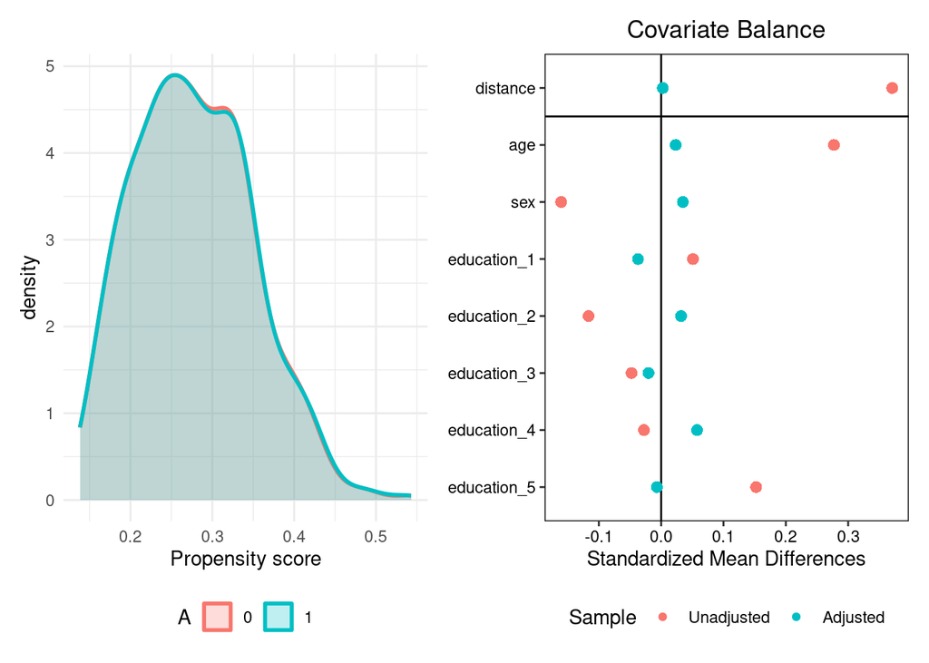

Figure 4: Covariate balance after nearest neighbor 1:1 matching

```r
plot_nn_after <- ggplot(
  md_nn,
  aes(x = distance, fill = factor(qsmk), color = factor(qsmk))
) +
  geom_density(aes(weight = weights), alpha = 0.25, linewidth = 1) +
  labs(x = "Propensity score", y = "density", fill = "A", color = "A") +
  theme_minimal() +
  theme(legend.position = "bottom")

plot_nn <- love.plot(m_nn, binary = "std") +
  theme(legend.position = "bottom")

### Put PS overlap + Love plot on the same line (patchwork package)
plot_nn_after + plot_nn + plot_layout(ncol = 2)
```

### 6.1.2 Nearest neighbour matching 1:1 with caliper

Here, the absolute difference in PS between patients in the same pair has to be lower than a specific threshold (the caliper). This can avoid poor matches in low-overlap regions and improves internal validity. The issue is that some patients may remain unmatched and are excluded.

```r
m_nn_cal <- matchit(
  qsmk ~ age + sex + education,
  data = df,
  method = "nearest",
  distance = df$ps,
  caliper = 0.2,
  ratio = 1
)

summary(m_nn_cal)
```

```
Call:
matchit(formula = qsmk ~ age + sex + education, data = df, method = "nearest",
    distance = df$ps, caliper = 0.2, ratio = 1)

Summary of Balance for All Data:
           Means Treated Means Control Std. Mean Diff. Var. Ratio eCDF Mean
distance          0.2772        0.2505          0.3707     1.0241    0.1035
age              46.1737       42.7885          0.2771     1.0731    0.0690
sex0              0.5459        0.4660          0.1604          .    0.0799
sex1              0.4541        0.5340         -0.1604          .    0.0799
education1        0.2010        0.1806          0.0510          .    0.0204
education2        0.1836        0.2287         -0.1165          .    0.0451
education3        0.3896        0.4127         -0.0475          .    0.0231
education4        0.0720        0.0791         -0.0277          .    0.0071
education5        0.1538        0.0989          0.1523          .    0.0550
           eCDF Max
distance     0.1757
age          0.1296
sex0         0.0799
sex1         0.0799
education1   0.0204
education2   0.0451
education3   0.0231
education4   0.0071
education5   0.0550

Summary of Balance for Matched Data:
           Means Treated Means Control Std. Mean Diff. Var. Ratio eCDF Mean
distance          0.2772        0.2770          0.0027     1.0054    0.0008
age              46.1737       45.8883          0.0234     1.0197    0.0089
sex0              0.5459        0.5633         -0.0349          .    0.0174
sex1              0.4541        0.4367          0.0349          .    0.0174
education1        0.2010        0.2159         -0.0372          .    0.0149
education2        0.1836        0.1712          0.0320          .    0.0124
education3        0.3896        0.3995         -0.0204          .    0.0099
education4        0.0720        0.0571          0.0576          .    0.0149
education5        0.1538        0.1563         -0.0069          .    0.0025
           eCDF Max Std. Pair Dist.
distance     0.0124          0.0036
age          0.0298          0.2476
sex0         0.0174          0.2741
sex1         0.0174          0.2741
education1   0.0149          0.2477
education2   0.0124          0.1346
education3   0.0099          0.2035
education4   0.0149          0.1536
education5   0.0025          0.3095

Sample Sizes:
          Control Treated
All          1163     403
Matched       403     403
Unmatched     760       0
Discarded       0       0
```

```r
bal_nn_cal <- bal.tab(
  m_nn_cal,
  estimand = "ATE",
  un = TRUE # show unadjusted + adjusted
)

bal_nn_cal
```

```
Balance Measures
                Type Diff.Un Diff.Adj
distance    Distance  0.3729   0.0027
age          Contin.  0.2820   0.0238
sex           Binary -0.0799   0.0174
education_1   Binary  0.0204  -0.0149
education_2   Binary -0.0451   0.0124
education_3   Binary -0.0231  -0.0099
education_4   Binary -0.0071   0.0149
education_5   Binary  0.0550  -0.0025

Sample sizes
          Control Treated
All          1163     403
Matched       403     403
Unmatched     760       0
```

```r
#' After 1:1 nearest neighbor matching with caliper,
#' check treatment effect on the matched sample.
md_nn_cal <- match.data(m_nn_cal)

ate_nn_cal <- lm(
  wt82_71 ~ qsmk,
  data = md_nn_cal,
  weights = weights # equal to 1 as ratio is 1
)

summary(ate_nn_cal)
```

```
Call:
lm(formula = wt82_71 ~ qsmk, data = md_nn_cal, weights = weights)

Residuals:
    Min      1Q  Median      3Q     Max
-31.627  -4.159   0.067   4.435  42.986

Coefficients:
            Estimate Std. Error t value Pr(>|t|)
(Intercept)   1.1249     0.4001   2.812  0.00505 **
qsmk          3.4002     0.5658   6.009 2.82e-09 ***
---
Signif. codes:  0 '***' 0.001 '**' 0.01 '*' 0.05 '.' 0.1 ' ' 1

Residual standard error: 8.032 on 804 degrees of freedom
Multiple R-squared:  0.04299,   Adjusted R-squared:  0.0418
F-statistic: 36.11 on 1 and 804 DF,  p-value: 2.821e-09
```

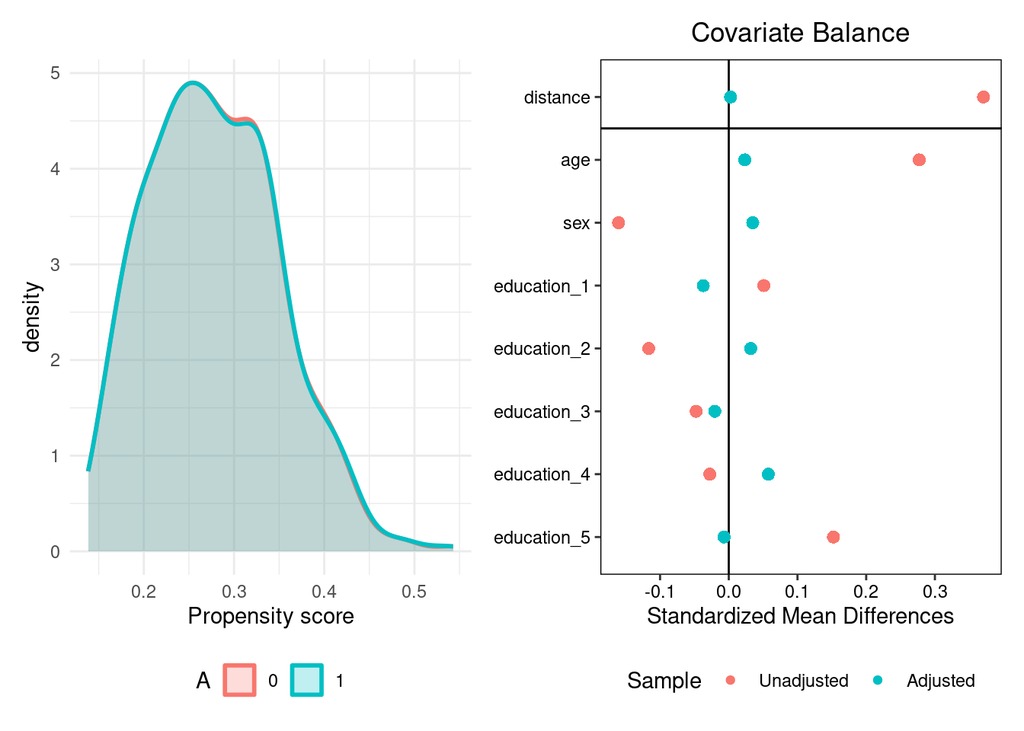

Figure 5: Covariate balance after nearest neighbor 1:1 matching with caliper

```r
plot_nn_cal_after <- ggplot(
  md_nn_cal,
  aes(x = distance, fill = factor(qsmk), color = factor(qsmk))
) +
  geom_density(aes(weight = weights), alpha = 0.25, linewidth = 1) +
  labs(x = "Propensity score", y = "density", fill = "A", color = "A") +
  theme_minimal() +
  theme(legend.position = "bottom")

plot_nn_cal <- love.plot(m_nn_cal, binary = "std") +
  theme(legend.position = "bottom")

### Put PS overlap + Love plot on the same line (patchwork package)
plot_nn_cal_after + plot_nn_cal + plot_layout(ncol = 2)
```

### 6.1.3 Optimal Matching

Advantages of optimal pair matching include that the matching order is not required to be specified and it is less likely that extreme within-pair distances will be large, unlike with nearest neighbor matching. Generally, however, as a subset selection method, optimal pair matching tends to perform similarly to nearest neighbor matching in that similar subsets of units will be selected to be matched.

#### 6.1.3.1 Optimal matching 1:1

Pairs are made in order to limit the overall difference across pairs (optimization model).

```r
# 1:1 optimal PS matching with exact matching on sex
#' more options can be checked at:
#'  https://kosukeimai.github.io/MatchIt/index.html

m_opt <- matchit(
  qsmk ~ age + sex + education,
  data = df,
  method = "optimal",
  exact = ~sex
)

m_opt
```

```
A `matchit` object
 - method: 1:1 optimal pair matching
 - distance: Propensity score
             - estimated with logistic regression
 - number of obs.: 1566 (original), 806 (matched)
 - target estimand: ATT
 - covariates: age, sex, education
```

```r
#' After optimal matching 1:1,
#' check treatment effect on the matched sample.
m_opt_df <- match.data(m_opt)

ate_m_opt <- lm(
  wt82_71 ~ qsmk,
  data = m_opt_df,
  weights = weights
)

summary(ate_m_opt)
```

```
Call:
lm(formula = wt82_71 ~ qsmk, data = m_opt_df, weights = weights)

Residuals:
    Min      1Q  Median      3Q     Max
-31.863  -4.044  -0.112   3.981  42.986

Coefficients:
            Estimate Std. Error t value Pr(>|t|)
(Intercept)   1.3610     0.3890   3.499 0.000493 ***
qsmk          3.1641     0.5501   5.752 1.25e-08 ***
---
Signif. codes:  0 '***' 0.001 '**' 0.01 '*' 0.05 '.' 0.1 ' ' 1

Residual standard error: 7.809 on 804 degrees of freedom
Multiple R-squared:  0.03952,   Adjusted R-squared:  0.03833
F-statistic: 33.08 on 1 and 804 DF,  p-value: 1.254e-08
```

#### 6.1.3.2 Optimal matching with fixed ratio (1:M)

Each patient from the smallest group can be matched with either 1 or many patients of the other group.

```r
# 1:2 matching (each treated matched with up to 2 controls).
m_opt_1m <- matchit(
  qsmk ~ age + sex + education,
  data = df,
  method = "optimal",
  ratio = 2
)

m_opt_1m
```

```
A `matchit` object
 - method: 2:1 optimal pair matching
 - distance: Propensity score
             - estimated with logistic regression
 - number of obs.: 1566 (original), 1209 (matched)
 - target estimand: ATT
 - covariates: age, sex, education
```

```r
#' After optimal matching 1:1,
#' check treatment effect on the matched sample.
m_opt_1m_df <- match.data(m_opt_1m)

ate_m_opt_1m <- lm(
  wt82_71 ~ qsmk,
  data = m_opt_1m_df,
  weights = weights
)

summary(ate_m_opt_1m)
```

```
Call:
lm(formula = wt82_71 ~ qsmk, data = m_opt_1m_df, weights = weights)

Residuals:
    Min      1Q  Median      3Q     Max
-42.513  -3.957   0.125   4.548  47.306

Coefficients:
            Estimate Std. Error t value Pr(>|t|)
(Intercept)   1.2320     0.2781   4.430 1.03e-05 ***
qsmk          3.2930     0.4817   6.837 1.28e-11 ***
---
Signif. codes:  0 '***' 0.001 '**' 0.01 '*' 0.05 '.' 0.1 ' ' 1

Residual standard error: 7.895 on 1207 degrees of freedom
Multiple R-squared:  0.03728,   Adjusted R-squared:  0.03648
F-statistic: 46.74 on 1 and 1207 DF,  p-value: 1.284e-11
```

### 6.1.4 Variable ratio optimal matching (true 1:M or full matching)

To allow each treated to have different numbers of controls.

```r
m_var_ratio <- matchit(
  qsmk ~ age + sex + education,
  data = df,
  method = "full"
)
```

```r
#' After optimal varaible ratio,
#' check treatment effect on the matched sample.
m_opt_var_ratio <- match.data(m_var_ratio)

ate_m_opt_var_ratio <- lm(
  wt82_71 ~ qsmk,
  data = m_opt_var_ratio,
  weights = weights
)

summary(ate_m_opt_var_ratio)
```

```
Call:
lm(formula = wt82_71 ~ qsmk, data = m_opt_var_ratio, weights = weights)

Weighted Residuals:
    Min      1Q  Median      3Q     Max
-53.609  -2.776   0.504   3.635  42.986

Coefficients:
            Estimate Std. Error t value Pr(>|t|)
(Intercept)   1.0553     0.2261   4.667 3.32e-06 ***
qsmk          3.4697     0.4458   7.784 1.27e-14 ***
---
Signif. codes:  0 '***' 0.001 '**' 0.01 '*' 0.05 '.' 0.1 ' ' 1

Residual standard error: 7.712 on 1564 degrees of freedom
Multiple R-squared:  0.0373,    Adjusted R-squared:  0.03668
F-statistic: 60.59 on 1 and 1564 DF,  p-value: 1.269e-14
```

## 6.2 Propensity Score Stratification

### 6.2.1 Outcome regression with stratum

Estimate the treatment effect in subsets of patients having similar values of PS, then combine them in an overall treatment effect. The total dataset is divided into mutually exclusive groups (strata), based on the estimated PS. Within the same stratum, the distribution of measured baseline covariates is similar between treated and control patients.

```r
# Most common approach: 5 groups, may eliminate ≈ 90% of the bias but strata may include very dissimilar patients.
df <- df %>%
  # Partition by PS (e.g., quantiles);
  mutate(
    ps_strata = cut(
      ps,
      breaks = quantile(ps, probs = seq(0, 1, 0.2)),
      include.lowest = TRUE,
      labels = FALSE
    )
  )

# Outcome regression with stratum
lm(wt82_71 ~ qsmk + factor(ps_strata), data = df)
```

```
Call:
lm(formula = wt82_71 ~ qsmk + factor(ps_strata), data = df)

Coefficients:
       (Intercept)                qsmk  factor(ps_strata)2  factor(ps_strata)3
            3.7831              3.2017             -0.6096             -2.0790
factor(ps_strata)4  factor(ps_strata)5
           -2.4195             -4.7520
```

### 6.2.2 Propensity Score Stratification (Subclassification ATE)

```r
# 1) Stratum-specific means and mean differences
tab_strat <- df %>%
  group_by(ps_strata, qsmk) %>%
  summarise(
    mean_y = mean(wt82_71, na.rm = TRUE),
    n = n(),
    .groups = "drop"
  ) %>%
  pivot_wider(
    names_from = qsmk,
    values_from = c(mean_y, n),
    names_sep = "_",
    values_fill = NA
  ) %>%
  mutate(
    MD = mean_y_1 - mean_y_0, # stratum-specific mean difference
    n_stratum = n_0 + n_1 # stratum size
  )

# 3) Subclassification ATE = weighted average of stratum-specific MDs (weights = stratum size)
ATE_subclass <- with(
  tab_strat,
  sum((n_stratum / sum(n_stratum, na.rm = TRUE)) * MD, na.rm = TRUE)
)

cat("\n=== PS subclassification (quintiles) – ATE (mean difference) ===\n")
```

```
=== PS subclassification (quintiles) – ATE (mean difference) ===
```

```r
print(ATE_subclass)
```

```
[1] 3.16593
```

```r
cat("\nStratum-specific table:\n")
```

```
Stratum-specific table:
```

```r
print(tab_strat %>% arrange(ps_strata))
```

```
# A tibble: 5 × 7
  ps_strata mean_y_0 mean_y_1   n_0   n_1    MD n_stratum
      <int>    <dbl>    <dbl> <int> <int> <dbl>     <int>
1         1    3.87      6.49   265    49  2.62       314
2         2    3.29      5.91   252    62  2.62       314
3         3    1.37      5.85   234    83  4.48       317
4         4    1.26      4.81   217    91  3.55       308
5         5   -0.726     1.83   195   118  2.56       313
```

Stratification estimates a weighted average of within-stratum effects.

## 6.3 Propensity Score as covariate (linear)

Include PS as continuous covariate in outcome regression. Raises the question of the relationship between the PS and the outcome. Even though is simpler and include all subjects, potential bias may arise if functional form is misspecified. Moreover, is difficult to assess if PS worked

```r
## PS as covariate (linear)
fit_ps_lin <- lm(wt82_71 ~ qsmk + ps, data = df)

fit_ps_lin %>%
  tidy(conf.int = TRUE) %>%
  filter(term == "qsmk")
```

```
# A tibble: 1 × 7
  term  estimate std.error statistic  p.value conf.low conf.high
  <chr>    <dbl>     <dbl>     <dbl>    <dbl>    <dbl>     <dbl>
1 qsmk      3.14     0.448      7.00 3.69e-12     2.26      4.01
```

## 6.4 Inverse Probability Weighting and Balancing

Create a “pseudo-population” where the distribution of measured baseline covariates is almost perfectly balanced. Every patient is assigned with a weight equal to the inverse of the probability of receiving the treatment that actually received.

### 6.4.1 General IPTW (unstablized)

*Note: May be inaccurate or unstable for patients with very low or very high PS.*

```r
df <- df %>%
  mutate(
    w_uiptw = ifelse(qsmk == 1, 1 / ps, 1 / (1 - ps))
  )
```

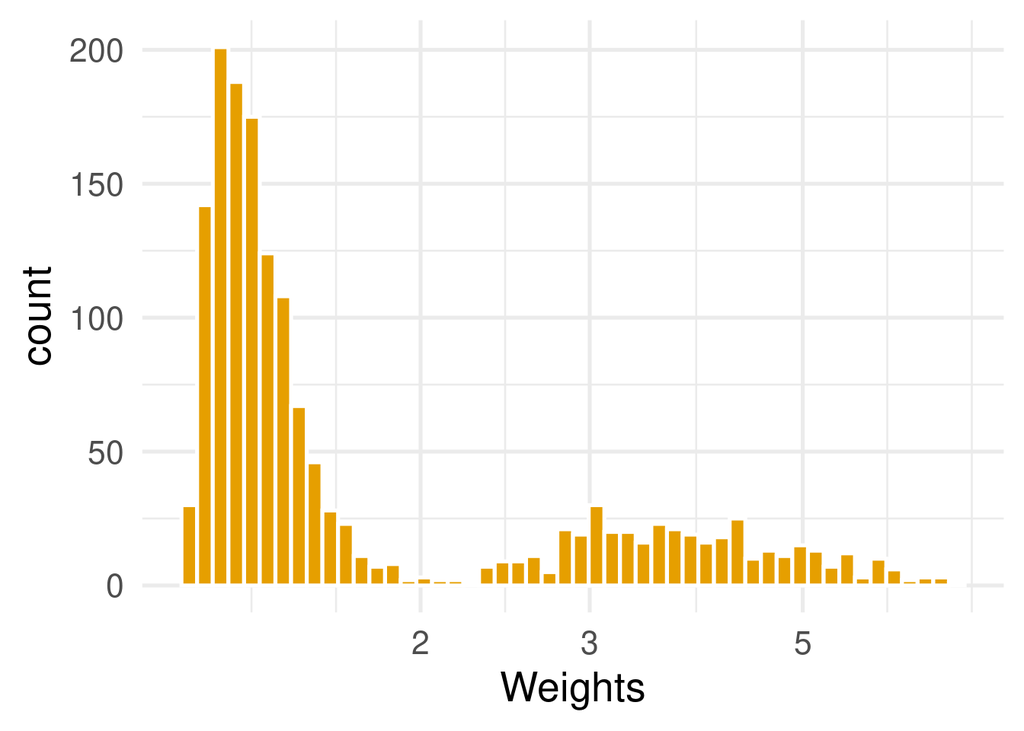

Figure 6: Distribution of unstabilized weights

```r
ggplot(df, aes(w_uiptw)) +
  geom_histogram(color = "white", fill = "#E69F00", bins = 50) +
  #  use a log scale for the x axis
  scale_x_log10() +
  theme_minimal(base_size = 20) +
  xlab("Weights")
```

```r
ate_iptw <- lm(wt82_71 ~ qsmk, data = df, weights = w_uiptw)
summary(ate_iptw)
```

```
Call:
lm(formula = wt82_71 ~ qsmk, data = df, weights = w_uiptw)

Weighted Residuals:
    Min      1Q  Median      3Q     Max
-62.683  -5.349  -0.013   5.325  81.792

Coefficients:
            Estimate Std. Error t value Pr(>|t|)
(Intercept)   1.8277     0.2878   6.350 2.82e-10 ***
qsmk          3.1183     0.4076   7.651 3.46e-14 ***
---
Signif. codes:  0 '***' 0.001 '**' 0.01 '*' 0.05 '.' 0.1 ' ' 1

Residual standard error: 11.39 on 1564 degrees of freedom
Multiple R-squared:  0.03608,   Adjusted R-squared:  0.03546
F-statistic: 58.54 on 1 and 1564 DF,  p-value: 3.465e-14
```

```r
# Balance diagnostics (unstabilized IPTW)
bal_iptw <- bal.tab(
  qsmk ~ age + sex + education,
  data = df,
  weights = df$w_uiptw,
  estimand = "ATE",
  un = TRUE
)
bal_iptw
```

```
Balance Measures
               Type Diff.Un Diff.Adj
age         Contin.  0.2820   0.0073
sex          Binary -0.0799  -0.0003
education_1  Binary  0.0204  -0.0052
education_2  Binary -0.0451  -0.0039
education_3  Binary -0.0231   0.0024
education_4  Binary -0.0071   0.0026
education_5  Binary  0.0550   0.0041

Effective sample sizes
           Control Treated
Unadjusted 1163.    403.
Adjusted   1149.96  374.92
```

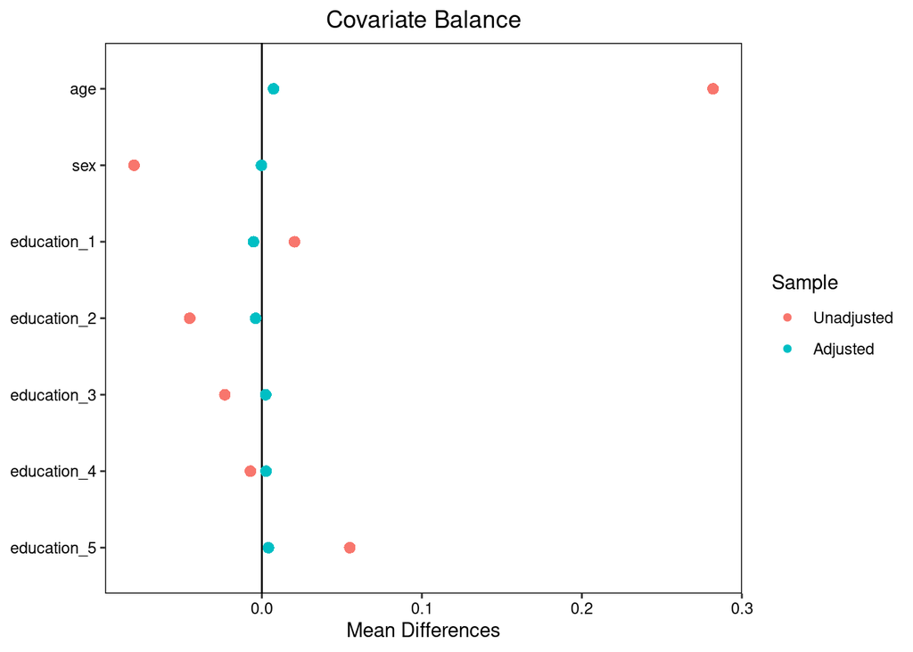

Figure 7: Covariate balance after unstabilized IPTW

```r
love.plot(bal_iptw, binary = "std")
```

### 6.4.2 IPTW Stabilized weights

Stabilized weights are often preferred because of its variance control, not bias correction.

*Note: same final results can be obtained using WeightIt package.*

```r
pA <- mean(df$qsmk)

df <- df %>%
  mutate(
    # calculate the stabilized weights
    w_siptw = ifelse(qsmk == 1, pA / ps, (1 - pA) / (1 - ps))
  )

# an alternative approach with same results by using propensity package
library(propensity)
df <- ps_model %>%
  # predict whether quit smoking
  augment(type.predict = "response", data = df) %>%
  # calculate inverse probability
  mutate(wts_st = wt_ate(.fitted, qsmk, stabilize = TRUE)) # default ustabilize
```

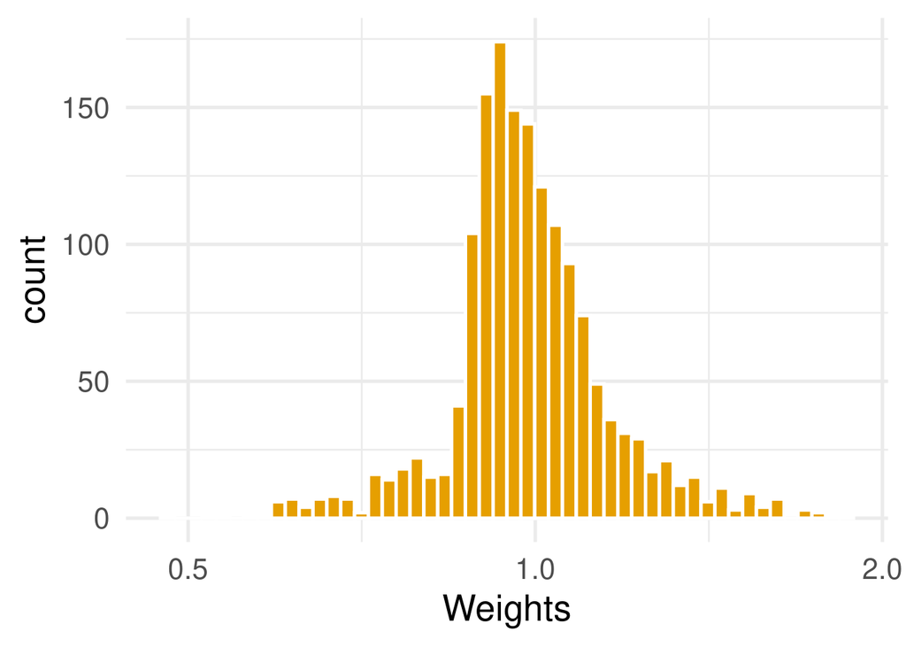

Figure 8: Distribution of stabilized weights

```r
ggplot(df, aes(w_siptw)) +
  geom_histogram(color = "white", fill = "#E69F00", bins = 50) +
  #  use a log scale for the x axis
  scale_x_log10() +
  theme_minimal(base_size = 20) +
  xlab("Weights")
```

```r
# Balance diagnostics (stabilized IPTW)
bal_siptw <- bal.tab(
  qsmk ~ age + sex + education,
  data = df,
  weights = df$w_siptw,
  method = "weighting",
  estimand = "ATE",
  un = TRUE
)

bal_siptw
```

```
Balance Measures
               Type Diff.Un Diff.Adj
age         Contin.  0.2820   0.0073
sex          Binary -0.0799  -0.0003
education_1  Binary  0.0204  -0.0052
education_2  Binary -0.0451  -0.0039
education_3  Binary -0.0231   0.0024
education_4  Binary -0.0071   0.0026
education_5  Binary  0.0550   0.0041

Effective sample sizes
           Control Treated
Unadjusted 1163.    403.
Adjusted   1149.96  374.92
```

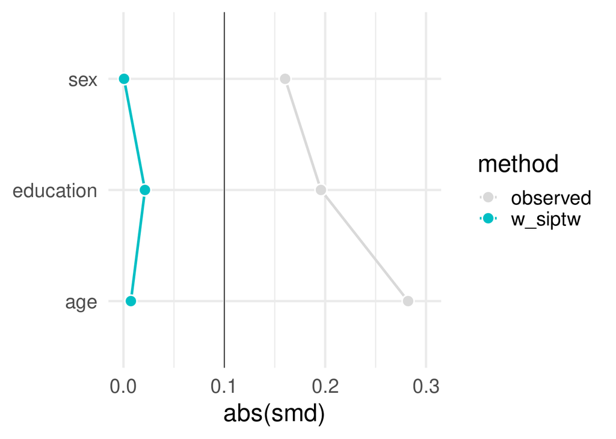

Figure 9: SMD osberved vs wts method

```r
# Note: tutorial

vars <- c("sex", "age", "education")

library(halfmoon)
plot_df <- df %>%
  tidy_smd(all_of(vars), .group = qsmk, .wts = w_siptw)

ggplot(
  data = plot_df,
  aes(x = abs(smd), y = variable, group = method, color = method, fill = method)
) +
  geom_line(orientation = "y", size = 1) +
  geom_point(size = 4, color = "white", shape = 21) +
  geom_vline(xintercept = 0.1, color = "black", linewidth = 0.3) +
  theme_minimal(base_size = 20) +
  theme(axis.title.y = element_blank()) +
  scale_color_manual(values = c("grey85", "#00BFC4")) +
  scale_fill_manual(values = c("grey85", "#00BFC4")) +
  xlim(0, .3)
```

#### 6.4.2.1 Causal effect estimation with IPW

In lm weighted regression the point estimate is correct, but the variance may be underestimated when weights represent sampling or IPW weights.

Thus after this the variance should be corrected, for example with robust SE approach or bootstrap.

##### 6.4.2.1.1 Weigthed regression wthout correction

```r
# Estimate causal effect with IPW
# fit lm mdoel with weights
ate_siptw <- lm(wt82_71 ~ qsmk, data = df, weights = w_siptw)

sipw_estimate <- ate_siptw %>%
  tidy(conf.int = TRUE) %>%
  filter(term == "qsmk")

# naive-incorrect-CI
sipw_estimate
```

```
# A tibble: 1 × 7
  term  estimate std.error statistic  p.value conf.low conf.high
  <chr>    <dbl>     <dbl>     <dbl>    <dbl>    <dbl>     <dbl>
1 qsmk      3.12     0.449      6.94 5.53e-12     2.24      4.00
```

##### 6.4.2.1.2 5.3.1.1.2 Weigthed regression with robust SEs (coeftest)

```r
# Correcting variance
# Note: there are pks for this, such as robustbase, gee, estimatr, etc.
library(sandwich)
library(lmtest)

# fix CI with robust SEs
ipw_model_robust <- coeftest(
  ate_siptw,
  vcov = vcovHC(ate_siptw, type = "HC0")
)

ipw_estimate_robust <- ipw_model_robust %>%
  tidy(conf.int = TRUE) %>%
  filter(term == "qsmk")

ipw_estimate_robust
```

```
# A tibble: 1 × 7
  term  estimate std.error statistic  p.value conf.low conf.high
  <chr>    <dbl>     <dbl>     <dbl>    <dbl>    <dbl>     <dbl>
1 qsmk      3.12     0.493      6.32 3.34e-10     2.15      4.09
```

##### 6.4.2.1.3 Weigthed regression with robust SEs with survey package

Designed for sampling weights and causal weights and uses robust (sandwich) variance estimators. This approach is more recommended for IPW workflow.

```r
library(survey)

des_ipw <- svydesign(ids = ~1, weights = ~w_siptw, data = df)
fit_ipw_svy <- svyglm(wt82_71 ~ qsmk, design = des_ipw, family = gaussian())


fit_ipw_svy_estimated <- fit_ipw_svy %>%
  tidy(conf.int = TRUE) %>%
  filter(term == "qsmk")

fit_ipw_svy_estimated
```

```
# A tibble: 1 × 7
  term  estimate std.error statistic  p.value conf.low conf.high
  <chr>    <dbl>     <dbl>     <dbl>    <dbl>    <dbl>     <dbl>
1 qsmk      3.12     0.493      6.32 3.38e-10     2.15      4.09
```

#### 6.4.2.2 Weigthed regression with bootstrap confidence intervals with rsample

```r
# following example from: https://github.com/r-causal/causal_inference_r_workshop/blob/master/slides/raw/01-causal_modeling_whole_game.qmd
fit_ipw <- function(.split, ...) {
  # get bootstrapped data frame
  .df <- as.data.frame(.split)

  # fit propensity score model
  propensity_model <- glm(
    qsmk ~ sex + age + education,
    family = binomial(),
    data = .df
  )

  # calculate inverse probability weights
  .df <- propensity_model %>%
    augment(type.predict = "response", data = .df) %>%
    mutate(wts = wt_ate(.fitted, qsmk))

  # fit correctly bootstrapped ipw model
  lm(wt82_71 ~ qsmk, data = .df, weights = wts) %>%
    tidy()
}

# fit ipw model to bootstrapped samples (rsample pkg)
ipw_results <- bootstraps(df, 500, apparent = TRUE) %>%
  mutate(results = map(splits, fit_ipw))

# get t-statistic-based CIs
boot_estimate <- int_t(ipw_results, results) %>%
  filter(term == "qsmk")

boot_estimate
```

```
# A tibble: 1 × 6
  term  .lower .estimate .upper .alpha .method
  <chr>  <dbl>     <dbl>  <dbl>  <dbl> <chr>
1 qsmk    2.22      3.13   4.11   0.05 student-t
```

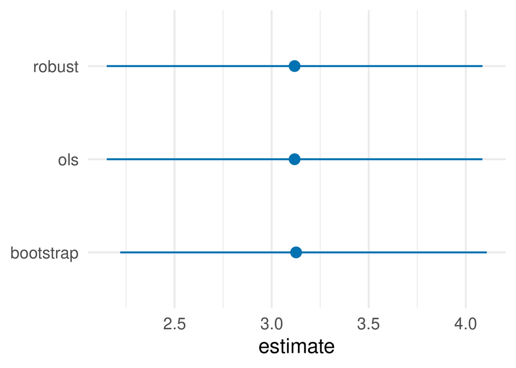

Final point estimate and CI95% are similar between 3 approaches: the causal effect estimate is 3.1 kg (95% CI 2.2 kg, 4.1 kg)

# 7 Double robust estimation method (AIPW)

Outcome regression can fail if the outcome model is misspecified and IPTW can fail if the PS model is misspecified or weights are unstable. Thus, methods combine both ideas so that if either the PS model or the outcome model is correct, the effect estimate is still consistent (if both are badly wrong, DR will also be wrong).

```r
# 1) Outcome regression models
# a. Estimate the outcome model among treated individuals (A = 1).
# This models E[Y | A = 1, Z], where Z = {age, sex, education}.
m1_model <- lm(
  wt82_71 ~ age + sex + education,
  data = df %>% filter(qsmk == 1)
)

# b. Estimate the outcome model among untreated individuals (A = 0).
# This models E[Y | A = 0, Z].
m0_model <- lm(
  wt82_71 ~ age + sex + education,
  data = df %>% filter(qsmk == 0)
)

# c. Predict potential outcomes
df$m1_hat <- predict(m1_model, newdata = df)
df$m0_hat <- predict(m0_model, newdata = df)

# 2) AIPW influence function
df$aipw_ic <-
  (df$m1_hat - df$m0_hat) +
  df$qsmk / df$ps * (df$wt82_71 - df$m1_hat) -
  (1 - df$qsmk) / (1 - df$ps) * (df$wt82_71 - df$m0_hat)

# 3) Estimate ATE
N <- nrow(df)
aipw_est <- mean(df$aipw_ic)
aipw_se <- sd(df$aipw_ic) / sqrt(N) # influence-function SE
aipw_ci <- c(
  aipw_est - 1.96 * aipw_se,
  aipw_est + 1.96 * aipw_se
)

aipw_est
```

```
[1] 3.127589
```

```r
aipw_ci
```

```
[1] 2.193295 4.061883
```

# 8 Appendix

## 8.1 LASSO logistic regression in PS estimation

When the number of covariates is large, estimating the propensity score with standard logistic regression can lead to unstable estimates and overfitting.

Penalized methods such as LASSO logistic regression introduce regularization that shrinks coefficients toward zero and can automatically exclude weak predictors. This can improve stability and predictive performance of the propensity score model, particularly in high-dimensional settings common in real-world data. Penalty levels should be chosen carefully (cross-validation, stability, sensitivity).

```r
# Prepare the design matrix
X <- model.matrix(
  qsmk ~ age + sex + education,
  data = df
)[, -1] # remove intercept

# Fit the LASSO model
# Select optimal penalty via cross-validation
cv_lasso <- cv.glmnet(
  X,
  df$qsmk,
  family = "binomial",
  alpha = 1
)

# Extract coefficients at the optimal λ
lasso_coef <- coef(cv_lasso, s = "lambda.min") # or lambda.1se (more regularized model)

# Extract coefficients and compare with ps_model
comp_table_lasso <- cbind(
  log_reg_ps = coef(ps_model),
  lasso_reg = as.vector(lasso_coef)
)

comp_table_lasso
```

```
             log_reg_ps  lasso_reg
(Intercept) -2.18033452 -1.9462863
age          0.02563373  0.0215182
sex1        -0.26257989 -0.1971913
education2  -0.10487154 -0.1158347
education3   0.11327233  0.0000000
education4   0.13632122  0.0000000
education5   0.60870454  0.4402681
```

Most coefficients are smaller in magnitude in the LASSO model compared with the standard logistic regression. For example, education has levels with a coefficient 0, meaning that LASSO considers these predictors not important for predicting treatment assignment.

## 8.2 Instrumental Variables (IV)

Propensity score methods rely on the assumption that all confounders are observed. If important confounders are unmeasured, these approaches can remain biased.

Instrumental variable methods provide an alternative identification strategy by using a variable that influences treatment assignment but affects the outcome only through treatment. Under certain assumptions, this creates as-if randomized variation in treatment that allows estimation of a causal effect even in the presence of unmeasured confounding.